# Economics and Conservation Tradeoffs

Module 09 — Social values, economic benefits, and who pays

NRES 315: Human Dimensions of Fish and Wildlife Management

October 21, 2026

## A streamside decision

A watershed partnership wants landowners to restore **riparian buffers**: vegetated strips beside streams.

Buffers may improve water quality and wildlife habitat. Landowners bear installation, maintenance, and foregone agricultural income.

**Who should pay for benefits that extend beyond the property?**

Source: Friday Case Brief 09; Chapter 10

## What you should be able to explain

- Connect earlier social values to economic value without treating them as identical.
- Explain how rights, costs, and incentives affect conservation.
- Distinguish price, nonmarket value, and who gains or pays.
- Compare alternatives and identify evidence that could change a recommendation.

Source: Chapters 1, 3, 6, 8, and 10

## The questions carry forward

**Module 01:** Which outcomes and actions do people consider desirable?

**Module 02:** Who benefits from public trust resources, now and in the future?

**Module 04:** How do values and evidence inform a decision?

**Module 09:** What benefits, costs, and tradeoffs follow from each choice?

Source: Chapters 1, 3, 6, and 10

## Social values and economic value

**Social values**

Beliefs about desirable outcomes and ways to act.

“We should leave healthy streams for future generations.”

**Economic value**

Benefits people derive from a resource or a specified change, reflected in tradeoffs.

“What would preserving this stream mean for people’s well-being?”

Values help explain **why an outcome matters**. Economic valuation examines **benefits and tradeoffs for a particular change**.

Source: Chapters 1 and 10

## From broad values to a specific choice

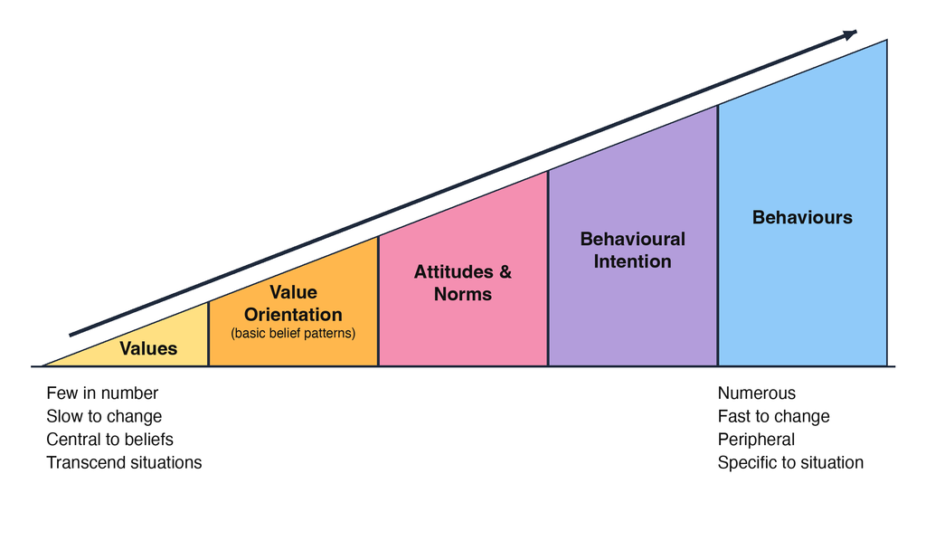

**Recall Module 07.**

Caring about stewardship can shape support for a buffer.

Enrollment also depends on costs, available time, control, and expected results.

A value orientation does not convert directly into a dollar amount.

Source: Chapters 8 and 10

## The same concern can produce different choices

Two landowners may both care about the stream.

One can afford to remove a strip from production. The other depends on that income and cannot cover installation.

**Willingness to pay reflects preferences and ability to pay.** A smaller dollar amount does not establish less concern.

An interview about stewardship and a valuation survey answer different questions.

Source: Chapters 8, 9, and 10

## Scarcity makes every choice a tradeoff

**Economics** examines how people allocate limited resources.

A buffer uses land, labor, time, and money that could serve another purpose.

**Opportunity cost:** the value of the next-best alternative given up. For a landowner, that may include foregone agricultural income.

A payment changes who pays; it does not remove the tradeoff.

Source: Chapter 10; Friday Case Brief 09

## How markets coordinate choices

**Demand:** quantity buyers are willing and able to buy at different prices.

**Supply:** quantity producers are willing to provide at different prices.

**Equilibrium:** quantity demanded equals quantity supplied.

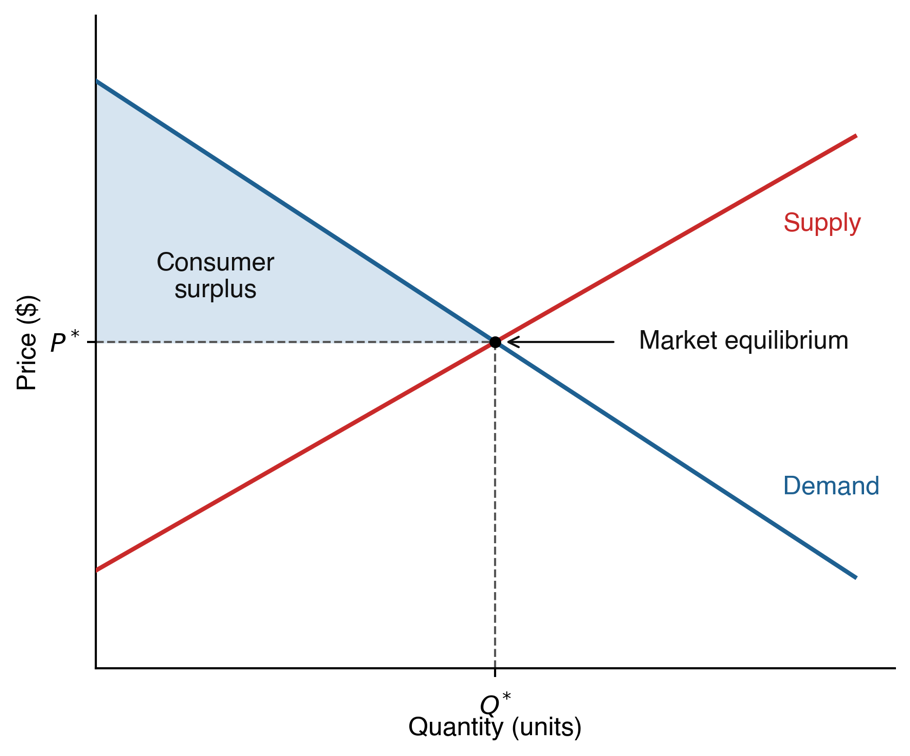

Source: Chapter 10

## Price and benefit are different quantities

**Consumer surplus** is willingness to pay minus the price actually paid.

Illustration: someone would pay **$30** for a visit and pays a **$10** fee. The surplus is **$20**, holding other costs aside.

The fee records a payment. It does not record the entire benefit of the visit.

Likewise, recreation spending alone misses benefits to users and nonusers.

Source: Chapter 10

## Economic value includes nonmarket benefits

**Market transactions:** crops, equipment, labor, or a paid recreation service.

**Nonmarket benefits:** an enjoyable wildlife encounter, cleaner water, or knowing habitat persists without a direct sale of that benefit.

One resource can provide both. **Market/nonmarket describes exchange; use/non-use describes how the benefit arises.**

Source: Chapter 10

## Use values: experience and ecological support

**Direct use:** fishing, hunting, wildlife viewing, or hiking.

**Indirect use:** ecological functions that support other benefits, such as nursery habitat supporting a fishery or wetlands reducing flood damage.

For our case, identify the **ecological change**, the **benefit**, and the **people receiving it**. Their magnitude still needs evidence.

Source: Chapter 10; Friday Case Brief 09

## Value can extend beyond current use

- **Option:** keeping the possibility of using the resource yourself later.
- **Bequest:** conserving it for future generations.
- **Existence:** valuing its continued existence even if you never use it.

A concern for future generations can motivate **bequest value**. A visitor count will not reveal that full benefit.

Source: Chapters 1, 3, and 10

## Value the change the decision would cause

**Total economic value** includes direct, indirect, option, bequest, and existence benefits.

**Marginal value** concerns an additional unit or increment.

The board needs the value of **additional restoration compared with no new program**, not the value of the entire watershed.

The next restored parcel need not provide the same benefit as the first.

Source: Chapter 10; Friday Case Brief 09

## Property rights shape the available choices

Rights may include **access, use, management, exclusion, and transfer**.

A landowner’s ability to manage a buffer is different from an angler’s right to enter that property.

A partnership’s ability to fund restoration is different from authority to require it.

Rights affect incentives, investment, and whose opportunities are protected.

Source: Chapters 3, 5, and 10; Friday Case Brief 09

## Two questions distinguish four kinds of goods

**Excludability:** can access be restricted? **Rivalry:** does one person’s use leave less for others?

**Private:** excludable + rivalrous.  
A harvested fish sold for food.

**Club:** excludable + largely non-rivalrous.  
Member access before congestion.

**Common-pool:** hard to exclude + rivalrous.  
A fish stock subject to harvest.

**Public:** hard to exclude + non-rivalrous.  
Climate-regulation benefits.

Source: Chapter 10

## Private incentives can miss public consequences

**Negative externality:** a decision imposes an uncompensated cost on others, such as downstream damage from runoff.

**Positive externality:** a decision benefits others without fully rewarding the provider, such as habitat benefits from a buffer.

**Social costs and benefits** include effects beyond the decision-maker. Here “social” means society-wide accounting.

Source: Chapter 10; Friday Case Brief 09

## A policy can change incentives in either direction

**Market failure:** unpriced harm encourages too much damaging activity, or unrewarded public benefits discourage conservation.

**Policy failure:** rules or subsidies create unintended harm.

A subsidy that lowers production costs may encourage expansion into habitat. A conservation payment may encourage restoration.

Ask what behavior the rule actually rewards.

Source: Chapter 10

## Why a cost-share offer might help

The landowner pays restoration costs while some benefits reach other people.

**Cost-share** reimburses part of eligible practice costs. **Payments for ecosystem services** pay for defined environmental services.

Both can change the incentive. Results still depend on participation, placement, maintenance, and whether the expected service occurs.

Source: Chapter 10; Friday Case Brief 09

## Pair check: values, benefits, and incentives

Consider this illustrative statement:

> “I want my grandchildren to have a healthy stream, but I cannot afford to take productive land out of use.”
1. Name the social value and a related economic value.
2. Identify the constraint and a cost-share incentive.
3. Explain why declining to enroll would not prove a lack of concern.

Source: Chapters 1, 8, and 10; Friday Case Brief 09

## Revealed preference: learn from actual choices

**Travel cost:** relate visits to travel expenses, fees, and time to infer recreation demand and benefits.

**Hedonic pricing:** isolate how environmental conditions relate to property prices while accounting for other features.

Observed choices help estimate use benefits. They miss people who value conservation but never visit or buy property there.

Source: Chapter 10

## Stated preference: ask about a defined change

**Contingent valuation:** ask whether people would pay a specified amount for a specified outcome.

**Choice experiment:** compare alternatives that vary in outcomes and cost.

These can include nonusers and future-oriented benefits. Credible scenarios, payment terms, and who is asked affect the result.

Source: Chapter 10

## Benefit transfer: use evidence from another setting

Apply a previous valuation study to the policy setting.

**Value transfer:** adapt an existing estimate. **Function transfer:** use a model that accounts for relevant differences.

Check the environmental change, affected population, substitutes, units, and time period. A convenient number is not automatically a suitable one.

Source: Chapter 10

## Choose the method for the missing benefit

**Recreation benefit:** travel-cost evidence may help.

**Existence or bequest benefit among nonvisitors:** a carefully designed stated-preference study may help.

**Landowner enrollment:** ask about costs and participation conditions.

The best next evidence may concern feasibility rather than valuation.

Source: Chapter 10; Friday Case Brief 09

## Benefit-cost analysis compares changes

1. Define the baseline, affected population, and time period.
2. Identify additional costs and benefits, including nonmarket effects.
3. Estimate those effects and put different years on a common basis.
4. Compare net benefits and report uncertainty and omitted effects.

**Net benefit = benefits − costs.** A financial budget alone does not provide the full comparison.

Source: Chapter 10

## Timing and uncertainty can change the result

Installation costs may occur now; habitat benefits may arrive later.

**Discounting** expresses effects in different years as present values. A higher discount rate gives less weight to later benefits and costs.

Compare plausible assumptions about costs, outcomes, timing, and durability. Report when the preferred alternative changes.

Source: Chapter 10

## A positive total does not settle fairness

**Efficiency:** do the added benefits justify the resource costs?

**Distribution:** who gains, who pays, and who is missing?

An alternative can have positive net benefits while imposing serious burdens on a particular group.

Recall public trust, inclusion, and governance: the decision also needs legitimate authority and a fair process.

Source: Chapters 3–6 and 10

## Changing the payer does not erase the cost

Under **A**, the partnership and enrolled landowner share installation costs.

Under **B**, the landowner pays installation costs; implementation still requires administration and enforcement.

For a society-wide account, record installation resources once and track how payment responsibilities shift.

Also identify maintenance, foregone income, and unequal ability to pay.

Source: Chapter 10; Friday Case Brief 09

## Compare the two restoration alternatives

**A: voluntary cost-share**

Participation depends on whether the offer works for landowners and whether needed parcels enroll.

**B: a buffer requirement**

Coverage depends on confirmed authority, implementation, and compliance.

With a partner: identify one likely tradeoff, one affected public, and the missing evidence that matters most to your choice.

Source: Friday Case Brief 09; Chapter 10

## Turn an information gap into a decision rule

Name **what to learn**, **how to learn it**, and **whose information is needed**.

Then state:

**If we found ___, we would revise ___ because ___.**

For example, poor enrollment on priority parcels would be a reason to reconsider an offer or the preferred alternative.

Source: Chapter 10; Friday Case Brief 09

## Bring the value connection back to the decision

**Social values** help define desirable outcomes and responsibilities.

**Economic values** describe benefits and tradeoffs for particular changes, including benefits without a market price.

**A management decision** combines that evidence with distribution, authority, and what affected publics consider acceptable.

Source: Chapters 1, 3, 6, 8, and 10

## Prepare for Friday, October 23

Read the **Case Brief** and find your preassigned group and role.

Submit the role record and four sections: **diagnosis; value and distribution; recommendation; evidence and revision**.

**Due before 10:50 a.m.** Shared response: **80 points**. Every present member completes the private **Group Check: 20 points**.

Identify the case evidence and chapter concept. Exact box or section numbers are not required.

Source: Friday Application 09 and Group Check 09

## Reference: a race to harvest

A shared catch limit may encourage people to harvest before others do.

Secure harvest shares can reduce that race and encourage longer-term planning.

But transfers can concentrate fishing rights. Ownership caps, community provisions, and entry protections address different distribution concerns.

Changing incentives and protecting communities require attention to design.

Source: Chapter 10

## Reference: accounting for an external cost

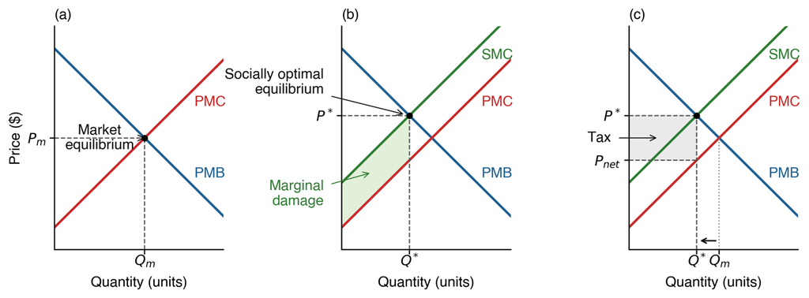

The unpriced harm creates a gap between **private cost** and **social cost**.

Source: Chapter 10

## Reference: rewarding an external benefit

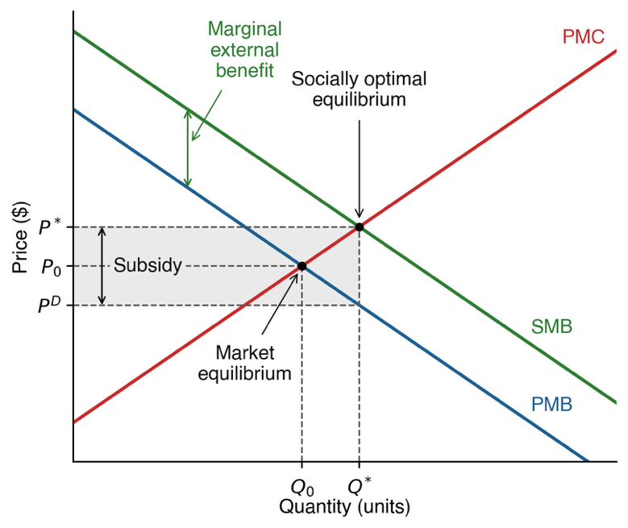

Benefits reach people beyond the provider.

A subsidy can reward some of that external benefit.

Actual payment design requires evidence about costs, additional outcomes, and participation.

Source: Chapter 10